# Exam 1

## Exam 1

#### Question

1. En La Tebaida se realizó un(a) estudio a un grupo de trabajadores de un(a) empresa sobre el tipo de bienes que poseen. Los(las) estadísticas se presentan en la gráfica.

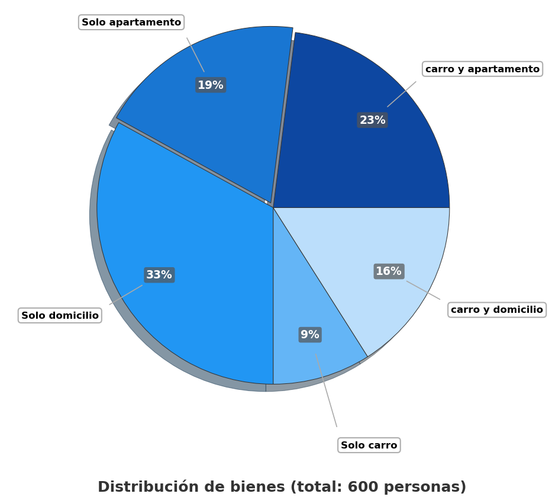

   Si 96 trabajadores de el(la) empresa poseen carro y domicilio, ¿cuántas personas poseen solo domicilio?
   1. 96
   2. 90
   3. 248
   4. 198

#### Solution

   Para resolver este problema, necesitamos aplicar proporciones y regla de tres a partir de la información dada en el gráfico circular y el enunciado. Seguiremos un proceso paso a paso:

### Paso 1: Identificar los datos conocidos:

   - Sabemos que 96 trabajadores poseen carro y domicilio.
   - Según el gráfico circular, este grupo representa el 16% del total.
   - También observamos en el gráfico que las personas que poseen solo domicilio representan el 33% del total.

### Paso 2: Calcular el número total de personas:

   Para encontrar el total de trabajadores en la empresa, utilizamos la siguiente relación de proporcionalidad:

   Si 16% del total = 96 trabajadores.

   Entonces 100% del total = X trabajadores

   Aplicando regla de tres:

   ```
   X = (valor_conocido × 100%) ÷ porcentaje_conocido
   X = (96 × 100%) ÷ 16%
   X = (96 × 100) ÷ 16
   X = 9600 ÷ 16
   X = 600.0000
   X = 600 trabajadores
   ```

   Por lo tanto, el total de trabajadores en la empresa es 600.

### Paso 3: Calcular el número de personas que poseen solo domicilio

   Una vez conocido el total, podemos calcular cuántas personas poseen solo domicilio utilizando el porcentaje correspondiente del gráfico circular:

   Si 100% del total = 600 trabajadores.

   Entonces 33% del total = Y trabajadores

   Aplicando regla de tres:

   ```
   Y = (porcentaje_buscado × total_personas) ÷ 100%
   Y = (33% × 600) ÷ 100%
   Y = (33 × 600) ÷ 100
   Y = 19800 ÷ 100
   Y = 198.0000
   Y = 198 trabajadores
   ```

### Paso 4: Verificación de la respuesta

   Podemos verificar nuestra respuesta comprobando que los números calculados son coherentes con los porcentajes del gráfico:
   - carro y apartamento: 138 trabajadores (23% del total)
   - Solo apartamento: 114 trabajadores (19% del total)
   - Solo domicilio: 198 trabajadores (33% del total)
   - Solo carro: 54 trabajadores (9% del total)
   - carro y domicilio: 96 trabajadores (16% del total)

   La suma de todas estas categorías es 600 trabajadores, que coincide exactamente con nuestro total calculado de 600 trabajadores.

### Conclusión

   Por lo tanto, 198 trabajadores de la empresa poseen solo domicilio.
   1. Falso
   2. Falso
   3. Falso
   4. Verdadero